# TFM: Used cars price prediction

# Introduction

The main objective of the project is to create a prediction model for the price of used cars in a internet portal.

This model would help portal users to set the best price to sell their vehicles.

The data has been downloaded from https://www.kaggle.com, and originally comes from https://www.ebay.de.

[figure not shown]

# The dataset

Original dataset will be composed of:

```
[1] "280602 samples and 15 features."
```

Features like **brand**, **model**, **type of vehicle**, **type of fuel**, number of **kilometers**, **age**, **power** or **location** will help to create a prediction model.

[figure not shown]

# The target

**Price** is the target variable. Will be able to predict it?

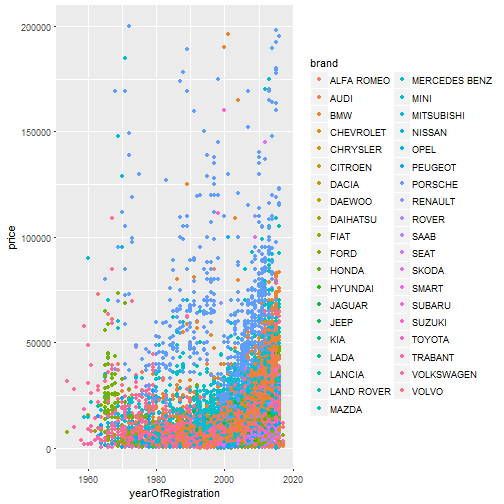

# The project

- **Data cleaning and exploration:** We will use **R** to manipulate data and prepae the datase for modelization.
- **Modelization:** Using **python** we will implement different regressors in order to get the best estimation of the price. Used algorithms will be:
- *Lineal regression*
- *Decission trees*
- *Random forests*
- **Output:** Using [Flask](http://flask.pocoo.org/) we will create an interface that allows users to introduce the features of their car and they will receive the estimated price.

# The repository

All the code and necessary data is available at this GitHub repository:  
https://github.com/rucoma/KSCHOOL_TFM_Used_Cars_Price

[figure not shown]

# Thank you!

[figure not shown]